# Continuous character models

Alex Faidiga

March 23, 2020

```r
library(ape) #utility fns
library(geiger) #utilty fns
library(OUwie)
```

Getting tree:

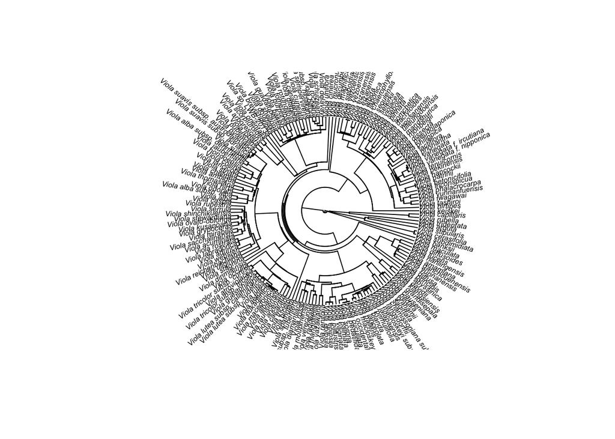

```r
setwd("~/Desktop/phylometh")
GBMB_tree <- read.tree("GBMB.tre")

all_tips_GBMB <- GBMB_tree$tip.label

viola_tips_GBMB <- all_tips_GBMB[grepl("Viola_", fixed = TRUE, GBMB_tree$tip.label)]

viola_node<-getMRCA(GBMB_tree, viola_tips_GBMB)
viola_tree<-extract.clade(GBMB_tree, viola_node)

plot(viola_tree, cex = 0.5, type = "fan")
```

Simulating continuous data because I do not have any. Let’s say this trait is plant height in cm. Log-transform.

```r
length(viola_tips_GBMB)
```

```
## [1] 173
```

```r
species_list <- viola_tree$tip.label
cont.data <- log(rnorm(n = 173, mean = 15, sd = 5))
names(cont.data) <- species_list
cont.data.vals <- unname(cont.data)
head(cont.data)
```

```
##       Viola_keiskei      Viola_hirtipes      Viola_tashiroi      Viola_iwagawai
##            1.932070            1.966979            2.515684            2.025647
## Viola_yunnanfuensis Viola_phalacrocarpa
##            2.342082            3.186146
```

Clean/visualize data:

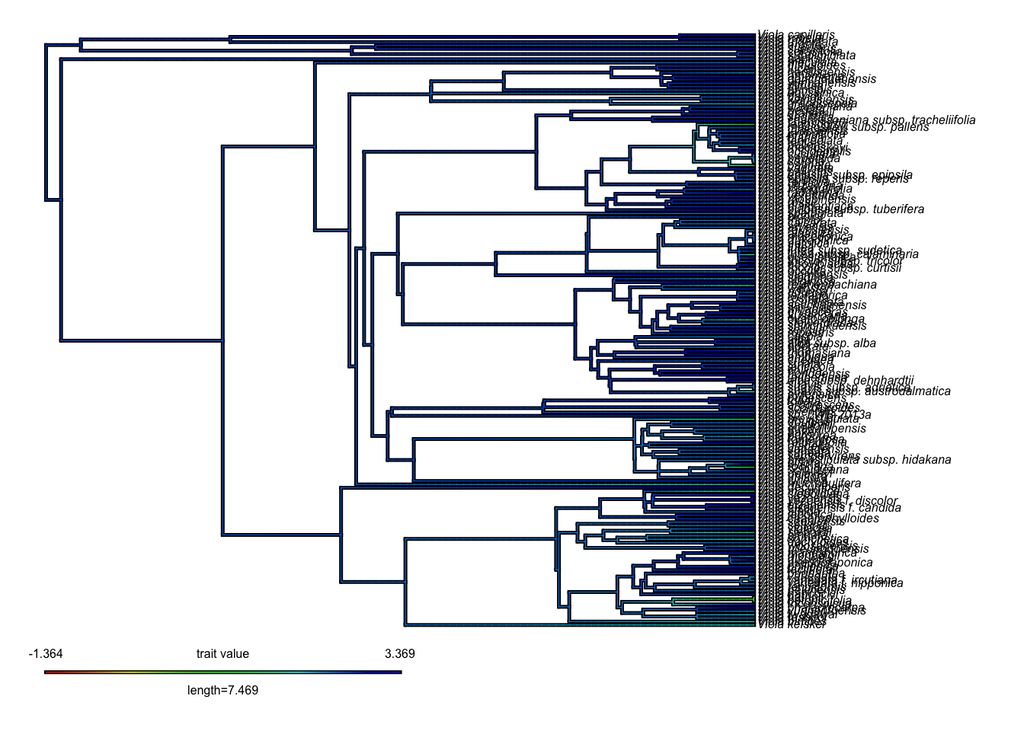

```r
vis.cont.data <- function(phy, data) {
  phytools::contMap(phy, data, fsize = 0.5, lwd = 0.5)
}

vis.cont.data(viola_tree, cont.data)
```

#### First, start basic. What is the rate of evolution of your trait on the tree?

```r
BM1 <- geiger::fitContinuous(viola_tree, cont.data, model="BM")
print(paste("The rate of evolution is", sqrt(BM1$opt[[1]]), "in units of cm/million years"))
```

```
## [1] "The rate of evolution is 2.45030814889545 in units of cm/million years"
```

```r
OU1 <- fitContinuous(viola_tree, cont.data, model="OU")
```

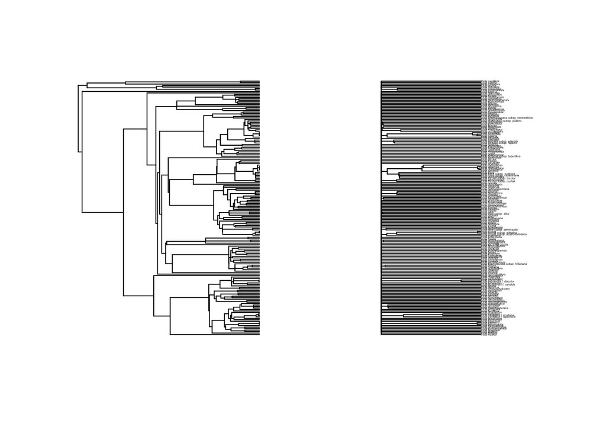

```r
par(mfcol = (c(1,2)))
plot(viola_tree, show.tip.label=FALSE)
ou.tree <- rescale(viola_tree, model="OU", alpha = OU1$opt[[1]])
plot(ou.tree, cex = 0.2)
```

#### Compare trees with AIC:

```r
AIC.BM1 <- BM1$opt[[6]]
AIC.OU1 <- OU1$opt[[7]]
AICvals <- c(AIC.BM1, AIC.OU1)
dAIC.BM1 <- AIC.BM1-min(AICvals)
dAIC.OU1 <- AIC.OU1-min(AICvals)

print(paste("The OU model is the better fit with a delta AIC value of", dAIC.OU1))
```

```
## [1] "The OU model is the better fit with a delta AIC value of 0"
```

#### This takes longer than you may be used to. We’re a bit obsessive about doing multiple starts and in general performing a thorough numerical search. It took you 3+ years to get the data, may as well take an extra five minutes to get an accurate answer.

#### First, we need to assign regimes. The way we do this is with ancestral state estimation of a discrete trait. We can do this using ace() in ape, or similar functions in corHMM or diversitree. Use only one discrete char.

```r
one.discrete.char <- rbinom(n=173, size=1, prob=0.3)
discrete.data <- data.frame(species_list, one.discrete.char, row.names = 1)
reconstruction.info <- ace(one.discrete.char, viola_tree, type="discrete", method="ML", CI=TRUE)
best.states <- colnames(reconstruction.info$lik.anc)[apply(reconstruction.info$lik.anc, 1, which.max)]
```

OUwie example data:

```r
data(tworegime)
plot(tree)
select.reg<-character(length(tree$node.label))
select.reg[tree$node.label == 1] <- "black"
select.reg[tree$node.label == 2] <- "red"
plot(tree)
nodelabels(pch=21, bg=select.reg)
```

```r
#Now fit an OU model that allows different sigma^2:
OUwie(tree,trait,model=c("OUMV"),root.station=TRUE)

#Fit an OU model based on a clade of interest:
OUwie(tree,trait,model=c("OUMV"), root.station=TRUE, clade=c("t50", "t64"))

#For large trees, it may be useful to have ways to restart the search (due to
#finite time per run on a computing cluster, for example). You can do this
#by changing settings of OUwie runs. For example:

run1 <- OUwie(tree,trait,model=c("OUMV"),root.station=TRUE, opts =
list("algorithm"="NLOPT_LN_SBPLX", "maxeval"="500", "ftol_abs"=0.001))

save(run1, file="run1.rda")

#Then, later or in a different session:

load("run1.rda")

run2 <- OUwie(tree,trait,model=c("OUMV"),root.station=TRUE, opts =
list("algorithm"="NLOPT_LN_SBPLX", "maxeval"="500", "ftol_abs"=0.001),
starting.vals=run1$new.start)

#run2 will start off where run1 stopped.

## End(Not run)
```

Now add these labels to your tree.

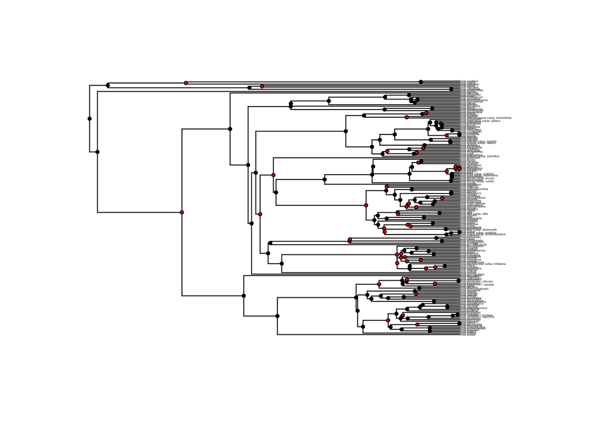

```r
viola_tree<-extract.clade(GBMB_tree, viola_node)
viola_tree$node.label <- best.states

select.reg<-character(length(viola_tree$node.label))
select.reg[viola_tree$node.label == 0] <- "black"
select.reg[viola_tree$node.label == 1] <- "red"
plot(viola_tree, cex = 0.2)
nodelabels(pch=21, cex = 0.5, bg=select.reg)
```

```r
OUwiedat <- data.frame(genus_species = viola_tree$tip.label, regime = one.discrete.char, cont.trait.val = cont.data.vals)

nodeBased.OUMV <- OUwie(viola_tree, OUwiedat, model="OUMV", simmap.tree=FALSE, diagn=FALSE)
```

```
## Initializing...
## Finished. Begin thorough search...
## Finished. Summarizing results.
```

```r
print(nodeBased.OUMV)
```

```
##
## Fit
##        lnL      AIC     AICc      BIC model ntax
##  -148.9191 307.8382 308.1975 323.6046  OUMV  173
##
##
## Rates
##                 0        1
## alpha    23.75909 23.75909
## sigma.sq 18.12327 11.96133
##
## Optima
##                   0          1
## estimate 2.60823384 2.55592298
## se       0.05664084 0.07394337
##
##
## Half life (another way of reporting alpha)
##          0          1
## 0.02917398 0.02917398
##
## Arrived at a reliable solution
```

#### What do the numbers mean?

For each selective regime, OUwie estiamates alpha, sigma squared, and theta. Theta is the optimal value toward which a continuous character is pulled, while alpha describes the strength of the pull toward that character. Sigma squared is the drift or “wiggle” parameter that describes how far the character stochastically drifts from the optimum value.

#### Now run all OUwie models:

```r
models <- c("BM1","BMS","OU1","OUM","OUMV","OUMA","OUMVA")
results <- lapply(models, OUwie, phy=viola_tree, data=OUwiedat)
```

```
## Initializing...
## Finished. Begin thorough search...
## Finished. Summarizing results.
```

```
## Initializing...
## Finished. Begin thorough search...
## Finished. Summarizing results.
## Initializing...
## Finished. Begin thorough search...
## Finished. Summarizing results.
## Initializing...
## Finished. Begin thorough search...
## Finished. Summarizing results.
## Initializing...
## Finished. Begin thorough search...
## Finished. Summarizing results.
## Initializing...
## Finished. Begin thorough search...
## Finished. Summarizing results.
## Initializing...
## Finished. Begin thorough search...
## Finished. Summarizing results.
```

```r
AIC.values<-sapply(results, "[[", "AIC")
AICc.values<-sapply(results, "[[", "AICc")

names(AICc.values)<-models
AICc.values<-AICc.values-min(AICc.values)

print(AICc.values) #The best model is the one with smallest AICc score
```

```
##      BM1      BMS      OU1      OUM     OUMV     OUMA    OUMVA
## 4991.350 4918.240 4358.279 4360.113 4359.339 4358.228    0.000
```

```r
best<-results[[which.min(AICc.values)]] #store for later
OUMV.results <- results[[5]]

print(best) #prints info on best model
```

```
##
## Fit
##       lnL       AIC      AICc       BIC model ntax
##  2031.824 -4051.647 -4051.141 -4032.728 OUMVA  173
##
##
## Rates
##                     0            1
## alpha    1.965312e+01 2.124183e+01
## sigma.sq 2.061993e-09 2.071346e-09
##
## Optima
##                 0        1
## estimate 1129.386 2.527682
## se            NaN      NaN
##
##
## Half life (another way of reporting alpha)
##          0          1
## 0.03526907 0.03263123
##
## Arrived at a reliable solution
```

#### We get SE for the optima (see nodeBased.OUMV$theta) but not for the other parameters. Let’s see how hard they are to estimate. First, look at ?OUwie.fixed to see how to calculate likelihood at a single point.

```r
?OUwie.fixed
#For each selective regime, OUwie estimates alpha, sigma squared, and theta. Theta is the optimal value toward which a continuous character is pulled, while alpha describes the strength of the pull toward that character. Sigma squared is the drift or "wiggle" parameter that describes how far the character stochastically drifts from the optimum value.
```

#### Next, keep all parameters but alpha at their maximum likelihood estimates (better would be to fix just alpha and let the others optimize given this constraint, but this is harder to program for this class). Try a range of alpha values and plot the likelihood against this.

```r
alpha.values<-seq(from= 20, to= 23.759, length.out=50)

likelihood.values <- rep(NA, length(alpha.values))

for (iteration in sequence(length(alpha.values))) {
    likelihood.values[iteration] <- OUwie.fixed(viola_tree, OUwiedat, model="OUMV", alpha=rep(alpha.values[iteration],2), sigma.sq=OUMV.results$solution[2,], theta=OUMV.results$theta[,1])$loglik
}
```

[output not shown]

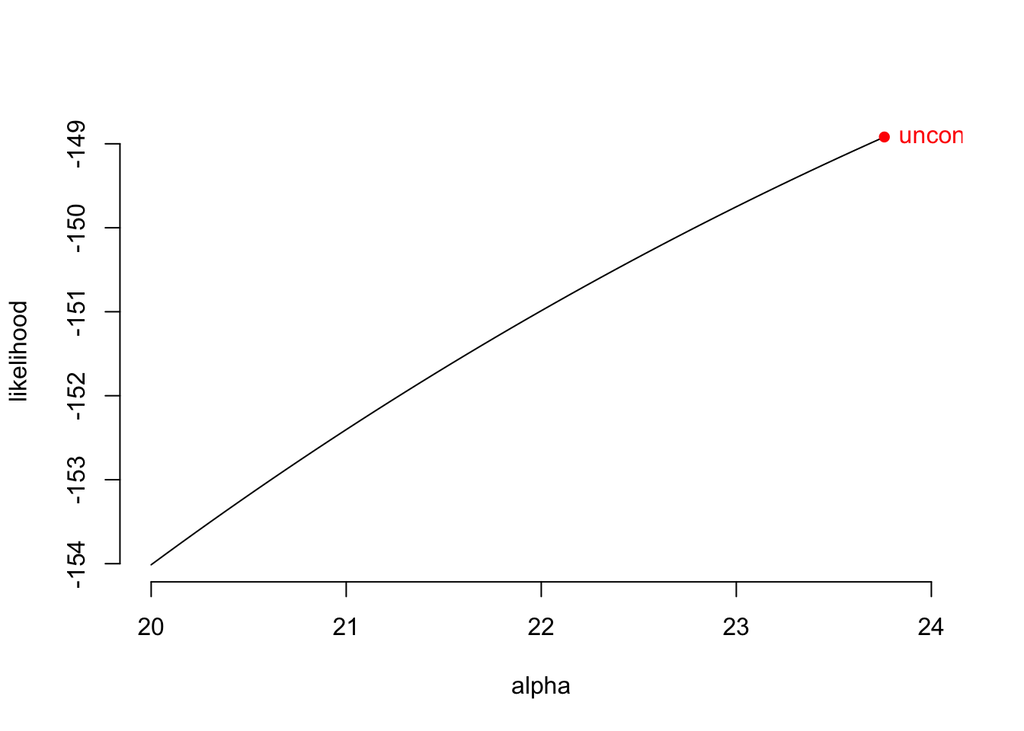

```r
plot(x= alpha.values , y= likelihood.values, xlab="alpha", ylab="likelihood", type="l", bty="n", xlim = c(20, 24))
points(x=OUMV.results$solution[1,1], y=OUMV.results$loglik, pch=16, col="red")
text(x=OUMV.results$solution[1,1], y=OUMV.results$loglik, "unconstrained best", pos=4, col="red")
```

#### A rule of thumb for confidence for likelihood is all points two log likelihood units worse than the best value. Draw a dotted line on the plot to show this

[figure not shown]

```r
plot(x= alpha.values , y= likelihood.values, xlab="alpha", ylab="likelihood", type="l", bty="n", xlim = c(20, 24), ylim = c(-76, -70))
points(x=OUMV.results$solution[1,1], y=OUMV.results$loglik, pch=16, col="red")
text(x=OUMV.results$solution[1,1], y=OUMV.results$loglik, "unconstrained best", pos=4, col="red")
abline(h=c(OUMV.results$loglik-2, OUMV.results$loglik+2), lty="dotted") #Two log-likelihood
```

#### Now, let’s try looking at both theta parameters at once, keeping the other parameters at their MLEs

```r
require("akima")
nreps<-400
theta1.points<-c(OUMV.results$theta[1,1], rnorm(nreps-1, OUMV.results$theta[1,1], 5*OUMV.results$theta[1,2])) #center on optimal value, have extra variance
theta2.points<-c(OUMV.results$theta[2,1], rnorm(nreps-1, OUMV.results$theta[2,1], 5*OUMV.results$theta[2,2])) #center on optimal value, have extra variance
likelihood.values<-rep(NA,nreps)

for (iteration in sequence(nreps)) {
    likelihood.values[iteration] <- OUwie.fixed(viola_tree, OUwiedat, model="OUMV", alpha=OUMV.results$solution[1,], sigma.sq=OUMV.results$solution[2,], theta=c(theta1.points[iteration], theta2.points[iteration]))$loglik
}
```

[output not shown]

[output cut: 345 more lines]

[output not shown]

#### Think of how long that took to do 400 iterations. Now remember how long the search took (longer).

```r
likelihood.differences<-(-(likelihood.values-max(likelihood.values)))
```

#### We are interpolating here: contour wants a nice grid. But by centering our simulations on the MLE values, we made sure to sample most thoroughly there

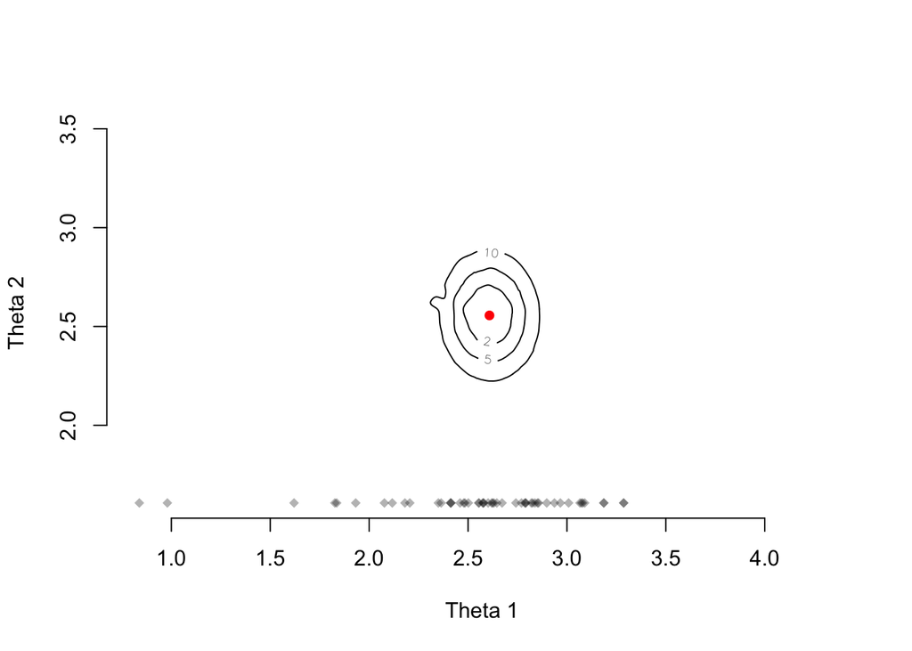

```r
interpolated.points<-interp(x=theta1.points, y=theta2.points, z= likelihood.differences, linear=FALSE, extrap=TRUE, xo=seq(min(theta1.points), max(theta1.points), length = 400), yo=seq(min(theta2.points), max(theta2.points), length = 400))

contour(interpolated.points, xlim=range(c(theta1.points, theta2.points)),ylim=range(c(theta1.points, theta2.points)), xlab="Theta 1", ylab="Theta 2", levels=c(2,5,10),add=FALSE,lwd=1, bty="n", asp=1)

points(x=OUMV.results$theta[1,1], y=OUMV.results$theta[2,1], col="red", pch=16)

points(x=OUwiedat$cont.trait.val[which(OUwiedat$regime==1)],y=rep(min(c(theta1.points, theta2.points)), length(which(OUwiedat$regime==1))), pch=18, col=rgb(0,0,0,.3)) #the tip values in regime 1, plotted along x axis
points(y=OUwiedat$cont.trait.val[which(OUwiedat$regime==2)],x=rep(min(c(theta1.points, theta2.points)), length(which(OUwiedat$regime==2))), pch=18, col=rgb(0,0,0,.3)) #the tip values in regime 2, plotted along y axis
```

#### The below only works if the discrete trait rate is low, so you have a good chance of estimating where the state is. If it evolves quickly, hard to estimate where the regimes are, so some in regime 1 are incorrectly mapped in regime 2 vice versa. This makes the models more similar than they should be. See Revell 2013, DOI:10.1093/sysbio/sys084 for an exploration of this effect.

```r
library(phytools)
```

```r
trait.ordered<-data.frame(OUwiedat[,2], OUwiedat[,2],row.names=OUwiedat[,1])
trait.ordered<- trait.ordered[viola_tree$tip.label,]
z<-trait.ordered[,1]
names(z)<-rownames(trait.ordered)
tree.mapped<-make.simmap(viola_tree,z,model="ER",nsim=1)
```

```
## make.simmap is sampling character histories conditioned on the transition matrix
##
## Q =
##           0         1
## 0 -76.24859  76.24859
## 1  76.24859 -76.24859
## (estimated using likelihood);
## and (mean) root node prior probabilities
## pi =
##   0   1
## 0.5 0.5
```

```
## Done.
```

[figure not shown]

```r
leg<-c("black","red")
names(leg)<-c(1,2)
plotSimmap(tree.mapped,leg,pts=FALSE,ftype="off", lwd=1)
```

```r
simmapBased<-OUwie(tree.mapped,OUwiedat,model="OUMV", simmap.tree=TRUE, diagn=FALSE)
```

```
## Initializing...
## Finished. Begin thorough search...
## Finished. Summarizing results.
```

```r
print(simmapBased)
```

```
##
## Fit
##        lnL      AIC     AICc     BIC model ntax
##  -132.9693 275.9385 276.2978 291.705  OUMV  173
##
##
## Rates
##                 0         1
## alpha    23.75908 23.759078
## sigma.sq 23.96217  2.221332
##
## Optima
##                   0          1
## estimate 2.51011689 2.69918743
## se       0.08549695 0.06838919
##
##
## Half life (another way of reporting alpha)
##          0          1
## 0.02917399 0.02917399
##
## Arrived at a reliable solution
```

```r
print(best)
```

```
##
## Fit
##       lnL       AIC      AICc       BIC model ntax
##  2031.824 -4051.647 -4051.141 -4032.728 OUMVA  173
##
##
## Rates
##                     0            1
## alpha    1.965312e+01 2.124183e+01
## sigma.sq 2.061993e-09 2.071346e-09
##
## Optima
##                 0        1
## estimate 1129.386 2.527682
## se            NaN      NaN
##
##
## Half life (another way of reporting alpha)
##          0          1
## 0.03526907 0.03263123
##
## Arrived at a reliable solution
```